### *Udacity Project 5: Communicate Data Findings*

# Ford GoBike Data Exploration

## Overview

I will be gathering, assessing, cleaning, and then visualizing explanatorily a Ford GoBike data set provided by Udacity. The Ford GoBike is a public bike sharing system in San Francisco, East Bay, and San Jose. The system launched on June 28, 2017 as a means to make commuting in the bay area much more accessible. Ford Motor Company partnered up with each township to ensure residents could get around with ease!

### Investigation Overview:

In the overall investigation I will be exploring the time spent, distance traveled, and ages of each member of this bike sharing system. I will specifically be looking into the ages and distance traveled of each member, but will be exploring all aspects of this data to attempt to get a wide, yet also thorough view of this dataset.

### Dataset Overview:

I chose this dataset specifically because I am an avid bike rider, and often wonder if systems like this are useful in any way. Combined with my interest in urban planning, it was a no brainer. I need to do figure out how to calculate the ages of each rider currently, and then do the same for distance. This way I'll be able to see all of the strands of this specific thread of the datasets rope.

## Preliminary Wrangling

```python
# import all packages and set plots to be embedded inline
import numpy as np
import pandas as pd
import matplotlib.pyplot as plt
import seaborn as sb

%matplotlib inline

# displaying maximum rows and columns to be able to properly see all of the data
pd.set_option('display.max_columns', 16)
pd.set_option('display.max_rows', 183412)
```

```python
# loading dataset
trip = pd.read_csv('201902-fordgobike-tripdata.csv')

print(trip.shape)
print(trip.dtypes)
print(trip.head(5))
```

```
(183412, 16)
duration_sec                 int64
start_time                  object
end_time                    object
start_station_id           float64
start_station_name          object
start_station_latitude     float64
start_station_longitude    float64
end_station_id             float64
end_station_name            object
end_station_latitude       float64
end_station_longitude      float64
bike_id                      int64
user_type                   object
member_birth_year          float64
member_gender               object
bike_share_for_all_trip     object
dtype: object
   duration_sec                start_time                  end_time  \
0         52185  2019-02-28 17:32:10.1450  2019-03-01 08:01:55.9750
1         42521  2019-02-28 18:53:21.7890  2019-03-01 06:42:03.0560
2         61854  2019-02-28 12:13:13.2180  2019-03-01 05:24:08.1460
3         36490  2019-02-28 17:54:26.0100  2019-03-01 04:02:36.8420
4          1585  2019-02-28 23:54:18.5490  2019-03-01 00:20:44.0740

   start_station_id                                start_station_name  \
0              21.0  Montgomery St BART Station (Market St at 2nd St)
1              23.0                     The Embarcadero at Steuart St
2              86.0                           Market St at Dolores St
3             375.0                           Grove St at Masonic Ave
4               7.0                               Frank H Ogawa Plaza

   start_station_latitude  start_station_longitude  end_station_id  \
0               37.789625              -122.400811            13.0
1               37.791464              -122.391034            81.0
2               37.769305              -122.426826             3.0
3               37.774836              -122.446546            70.0
4               37.804562              -122.271738           222.0

                               end_station_name  end_station_latitude  \
0                Commercial St at Montgomery St             37.794231
1                            Berry St at 4th St             37.775880
2  Powell St BART Station (Market St at 4th St)             37.786375
3                        Central Ave at Fell St             37.773311
4                         10th Ave at E 15th St             37.792714

   end_station_longitude  bike_id   user_type  member_birth_year  \
0            -122.402923     4902    Customer             1984.0
1            -122.393170     2535    Customer                NaN
2            -122.404904     5905    Customer             1972.0
3            -122.444293     6638  Subscriber             1989.0
4            -122.248780     4898  Subscriber             1974.0

  member_gender bike_share_for_all_trip
0          Male                      No
1           NaN                      No
2          Male                      No
3         Other                      No
4          Male                     Yes
```

```python
trip.info()
```

```
<class 'pandas.core.frame.DataFrame'>
RangeIndex: 183412 entries, 0 to 183411
Data columns (total 16 columns):
 #   Column                   Non-Null Count   Dtype
---  ------                   --------------   -----
 0   duration_sec             183412 non-null  int64
 1   start_time               183412 non-null  object
 2   end_time                 183412 non-null  object
 3   start_station_id         183215 non-null  float64
 4   start_station_name       183215 non-null  object
 5   start_station_latitude   183412 non-null  float64
 6   start_station_longitude  183412 non-null  float64
 7   end_station_id           183215 non-null  float64
 8   end_station_name         183215 non-null  object
 9   end_station_latitude     183412 non-null  float64
 10  end_station_longitude    183412 non-null  float64
 11  bike_id                  183412 non-null  int64
 12  user_type                183412 non-null  object
 13  member_birth_year        175147 non-null  float64
 14  member_gender            175147 non-null  object
 15  bike_share_for_all_trip  183412 non-null  object
dtypes: float64(7), int64(2), object(7)
memory usage: 22.4+ MB
```

```python
# changing datatypes
# converting 'member_gender' and 'user_type' to categorical dtypes
ordinal_var_dict = {'user_type' : ['Subscriber', 'Customer'],
                    'member_gender' : ['Male', 'Female', 'Other']}

for var in ordinal_var_dict:
    ordered_var = pd.api.types.CategoricalDtype(ordered = True,
                                                categories = ordinal_var_dict[var])
    trip[var] = trip[var].astype(ordered_var)

# converting start_time and end_time to datetime dtypes
trip.start_time = pd.to_datetime(trip.start_time)
trip.end_time = pd.to_datetime(trip.end_time)

# converting bike_share_for_all_trip to bool
trip.bike_share_for_all_trip = (trip.bike_share_for_all_trip == 'Yes')

# converting start_station_name and end_station_name to string dtypes
trip['start_station_name'] = trip['start_station_name'].astype(str)
trip['end_station_name'] = trip['end_station_name'].astype(str)
```

```python
trip.info()
```

```
<class 'pandas.core.frame.DataFrame'>
RangeIndex: 183412 entries, 0 to 183411
Data columns (total 16 columns):
 #   Column                   Non-Null Count   Dtype
---  ------                   --------------   -----
 0   duration_sec             183412 non-null  int64
 1   start_time               183412 non-null  datetime64[ns]
 2   end_time                 183412 non-null  datetime64[ns]
 3   start_station_id         183215 non-null  float64
 4   start_station_name       183412 non-null  object
 5   start_station_latitude   183412 non-null  float64
 6   start_station_longitude  183412 non-null  float64
 7   end_station_id           183215 non-null  float64
 8   end_station_name         183412 non-null  object
 9   end_station_latitude     183412 non-null  float64
 10  end_station_longitude    183412 non-null  float64
 11  bike_id                  183412 non-null  int64
 12  user_type                183412 non-null  category
 13  member_birth_year        175147 non-null  float64
 14  member_gender            175147 non-null  category
 15  bike_share_for_all_trip  183412 non-null  bool
dtypes: bool(1), category(2), datetime64[ns](2), float64(7), int64(2), object(2)
memory usage: 18.7+ MB
```

### What is the structure of your dataset?

So it looks like there are 183,412 bike trips recorded in this dataset. Luckily there are 16 columns of data for me to play around with. I made sure I converted all of the non-string datatypes to their respective datatypes (ex: `user_type` was an object and is now a categorical datatype) with the exception of object to string as either way it will remain as an object.

The columns are as follows:

```
1. `duration_sec`
2. `start_time`
3. `end_time`
4. `start_station_id`
5. `start_station_name`
6. `start_station_latitude`
7. `start_station_longitude`
8. `end_station_id`
9. `end_station_name`
10. `end_station_latitude`
11. `end_station_longitude`
12. `bike_id`
13. `user_type`
14. `member_birth_year`
15. `member_gender`
16. `bike_share_for_all_trip`
```

### What is/are the main feature(s) of interest in your dataset?

Two main variables stand out to me when I look at the data thus far. Trip duration and age seem to be the most unique numerical variables. Diving into these two variables would be a great first step!

### What features in the dataset do you think will help support your investigation into your feature(s) of interest?

I think a big factor might be help would be finding out what the distance of each ride would be. One **could** assume that the duration of the trip and the distance would be directly cause/effect. Furthermore, I'd like to see how the member's age relates to both distance and duration of the trip.

## Univariate Exploration

First I'm going to add a quick function to make titling my plots much easier!

```python
def myPlt(title, xvar, yvar):
    plt.figure(figsize = [14.70, 8.27])
    plt.title(title)
    plt.xlabel(xvar)
    plt.ylabel(yvar);
```

### Duration

In this section, I'd like to take a look at the `duration_sec` of each trip.

```python
trip['duration_sec'].head()
```

```
0    52185
1    42521
2    61854
3    36490
4     1585
Name: duration_sec, dtype: int64
```

```python
#plotting
def duration():
    binsize = 500
    bins = np.arange(0, trip['duration_sec'].max()+binsize, binsize)
    plt.hist(data = trip, x = 'duration_sec', bins = bins)
    plt.axis([-500, 10000, 0, 90000])
    plt.show()
```

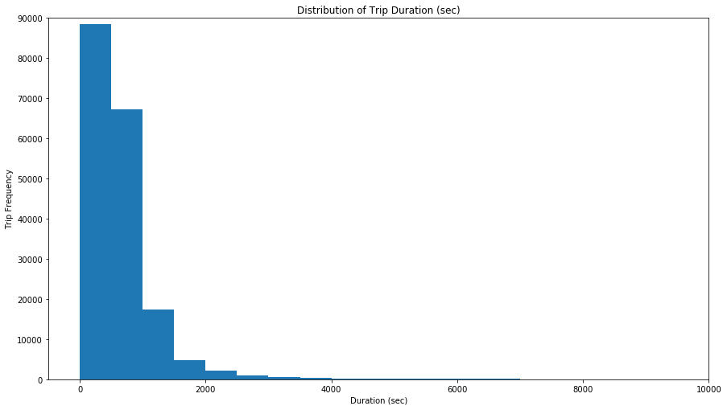

```python
myPlt('Distribution of Trip Duration (sec)', 'Duration (sec)', 'Trip Frequency')
duration()
```

As you can see the majority of trips were under 2000 seconds. I wonder now if the distance between start and end are equal for each trip. But before I look for that, I think showing a log scale plot might help shed a more focused light on what's happening between 0 and 2000 seconds.

```python
def dur_log():
    # plotting
    log_binsize = 0.05
    bins_log = 10 ** np.arange(2.4, np.log10(trip['duration_sec'].max()) + log_binsize, log_binsize)
    plt.hist(data = trip, x = 'duration_sec', bins = bins_log)
    plt.xscale('log')
    plt.xticks([500, 1e3, 2e3, 5e3, 1e4], [500, '1k', '2k', '5k', '10k'])
    plt.axis([0, 10000, 0, 15000])
    plt.show()
```

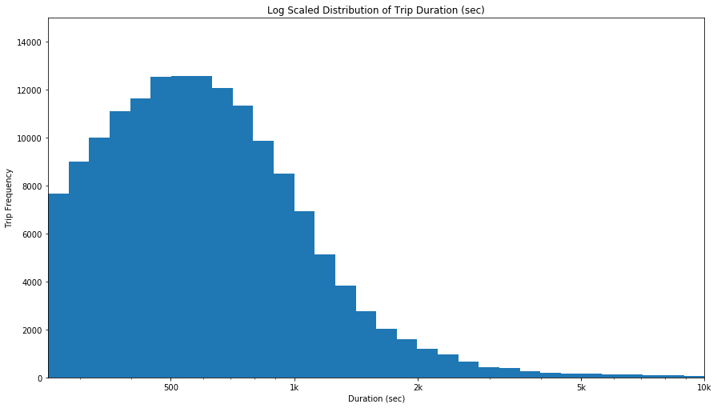

```python
myPlt('Log Scaled Distribution of Trip Duration (sec)', 'Duration (sec)', 'Trip Frequency')
dur_log()
```

```python
def deep_scale():
    binsize = 100
    bins = np.arange(0, trip['duration_sec'].max()+binsize, binsize)
    plt.hist(data = trip, x = 'duration_sec', bins = bins)
    plt.xlim([0, 1e3])
    plt.show()
```

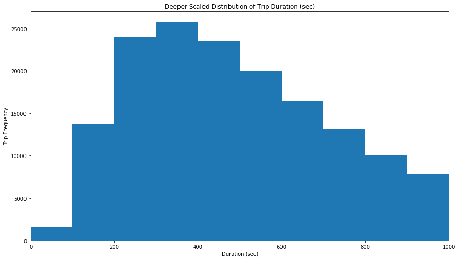

```python
myPlt("Deeper Scaled Distribution of Trip Duration (sec)", "Duration (sec)", "Trip Frequency");
deep_scale()
```

And, when I scale it even deeper you can see that most of the trips are in the 400 second area.

### Age

In this section I'd like to take a look the riders' ages. I'm definitely going to have to create a new column as there is no age column. So I'll be taking the already existing `member_birth_year` and subtracting each rider's birth year from 2021 (this year).

```python
trip['member_birth_year'].head()
```

```
0    1984.0
1       NaN
2    1972.0
3    1989.0
4    1974.0
Name: member_birth_year, dtype: float64
```

```python
trip.member_birth_year.value_counts()
```

```
1988.0    10236
1993.0     9325
1989.0     8972
1990.0     8658
1991.0     8498
1992.0     8250
1987.0     8018
1986.0     7973
1994.0     7660
1995.0     7423
1985.0     7028
1984.0     6562
1983.0     5954
1980.0     5024
1982.0     4990
1996.0     4640
1981.0     4345
1979.0     3756
1997.0     3481
1998.0     3208
1978.0     2830
1977.0     2725
1974.0     2633
1999.0     2528
1975.0     2503
1976.0     2442
1973.0     2080
1968.0     1928
1971.0     1924
1972.0     1909
2000.0     1678
1970.0     1590
1965.0     1546
1969.0     1414
1967.0     1315
1964.0     1189
1963.0     1151
1966.0      989
1962.0      956
1961.0      821
```

[output cut: 21 more lines]

```
1946.0       19
1902.0       11
1939.0       11
1941.0        9
1901.0        6
1938.0        3
1920.0        3
1934.0        2
1944.0        2
1930.0        1
1910.0        1
1927.0        1
1928.0        1
1878.0        1
Name: member_birth_year, dtype: int64
```

It looks like I've got to clean the `age` data up. So I'll be getting rid of the trips with NaN birth years, and birth years no earlier than 1940, as there are a number of years on this list that might not be entirely possible (of course I do not want to be ageist in any way. The data would just be cleaner to have a cut off year).

Then I'll make a new column, calculating the age by subtracting this year from the `member_birth_year`, and name it `age`.

```python
# removing rows with NaN years
trip = trip[trip['member_birth_year'].notna()]

# removing rows with birth years less than 1940
trip.drop(trip[trip.member_birth_year <= 1940.0].index, inplace = True)
```

```python
trip.head()
```

|  | duration_sec | start_time | end_time | start_station_id | start_station_name | start_station_latitude | start_station_longitude | end_station_id | end_station_name | end_station_latitude | end_station_longitude | bike_id | user_type | member_birth_year | member_gender | bike_share_for_all_trip |
| --- | --- | --- | --- | --- | --- | --- | --- | --- | --- | --- | --- | --- | --- | --- | --- | --- |
| 0 | 52185 | 2019-02-28 17:32:10.145 | 2019-03-01 08:01:55.975 | 21.0 | Montgomery St BART Station (Market St at 2nd St) | 37.789625 | -122.400811 | 13.0 | Commercial St at Montgomery St | 37.794231 | -122.402923 | 4902 | Customer | 1984.0 | Male | False |
| 2 | 61854 | 2019-02-28 12:13:13.218 | 2019-03-01 05:24:08.146 | 86.0 | Market St at Dolores St | 37.769305 | -122.426826 | 3.0 | Powell St BART Station (Market St at 4th St) | 37.786375 | -122.404904 | 5905 | Customer | 1972.0 | Male | False |
| 3 | 36490 | 2019-02-28 17:54:26.010 | 2019-03-01 04:02:36.842 | 375.0 | Grove St at Masonic Ave | 37.774836 | -122.446546 | 70.0 | Central Ave at Fell St | 37.773311 | -122.444293 | 6638 | Subscriber | 1989.0 | Other | False |
| 4 | 1585 | 2019-02-28 23:54:18.549 | 2019-03-01 00:20:44.074 | 7.0 | Frank H Ogawa Plaza | 37.804562 | -122.271738 | 222.0 | 10th Ave at E 15th St | 37.792714 | -122.248780 | 4898 | Subscriber | 1974.0 | Male | True |
| 5 | 1793 | 2019-02-28 23:49:58.632 | 2019-03-01 00:19:51.760 | 93.0 | 4th St at Mission Bay Blvd S | 37.770407 | -122.391198 | 323.0 | Broadway at Kearny | 37.798014 | -122.405950 | 5200 | Subscriber | 1959.0 | Male | False |

```python
# adding new age column
# subtracting 2021 (this year) from 'member_birth_year'

trip['age'] = (2021 - trip['member_birth_year'])
print(trip['age'].dtype)
trip.head()
```

```
float64
```

|  | duration_sec | start_time | end_time | start_station_id | start_station_name | start_station_latitude | start_station_longitude | end_station_id | ... | end_station_latitude | end_station_longitude | bike_id | user_type | member_birth_year | member_gender | bike_share_for_all_trip | age |
| --- | --- | --- | --- | --- | --- | --- | --- | --- | --- | --- | --- | --- | --- | --- | --- | --- | --- |
| 0 | 52185 | 2019-02-28 17:32:10.145 | 2019-03-01 08:01:55.975 | 21.0 | Montgomery St BART Station (Market St at 2nd St) | 37.789625 | -122.400811 | 13.0 | ... | 37.794231 | -122.402923 | 4902 | Customer | 1984.0 | Male | False | 37.0 |
| 2 | 61854 | 2019-02-28 12:13:13.218 | 2019-03-01 05:24:08.146 | 86.0 | Market St at Dolores St | 37.769305 | -122.426826 | 3.0 | ... | 37.786375 | -122.404904 | 5905 | Customer | 1972.0 | Male | False | 49.0 |
| 3 | 36490 | 2019-02-28 17:54:26.010 | 2019-03-01 04:02:36.842 | 375.0 | Grove St at Masonic Ave | 37.774836 | -122.446546 | 70.0 | ... | 37.773311 | -122.444293 | 6638 | Subscriber | 1989.0 | Other | False | 32.0 |
| 4 | 1585 | 2019-02-28 23:54:18.549 | 2019-03-01 00:20:44.074 | 7.0 | Frank H Ogawa Plaza | 37.804562 | -122.271738 | 222.0 | ... | 37.792714 | -122.248780 | 4898 | Subscriber | 1974.0 | Male | True | 47.0 |
| 5 | 1793 | 2019-02-28 23:49:58.632 | 2019-03-01 00:19:51.760 | 93.0 | 4th St at Mission Bay Blvd S | 37.770407 | -122.391198 | 323.0 | ... | 37.798014 | -122.405950 | 5200 | Subscriber | 1959.0 | Male | False | 62.0 |

5 rows × 17 columns

```python
trip['age'] = trip['age'].astype(int)
```

```python
trip.info()
```

```
<class 'pandas.core.frame.DataFrame'>
Int64Index: 174944 entries, 0 to 183411
Data columns (total 17 columns):
 #   Column                   Non-Null Count   Dtype
---  ------                   --------------   -----
 0   duration_sec             174944 non-null  int64
 1   start_time               174944 non-null  datetime64[ns]
 2   end_time                 174944 non-null  datetime64[ns]
 3   start_station_id         174749 non-null  float64
 4   start_station_name       174944 non-null  object
 5   start_station_latitude   174944 non-null  float64
 6   start_station_longitude  174944 non-null  float64
 7   end_station_id           174749 non-null  float64
 8   end_station_name         174944 non-null  object
 9   end_station_latitude     174944 non-null  float64
 10  end_station_longitude    174944 non-null  float64
 11  bike_id                  174944 non-null  int64
 12  user_type                174944 non-null  category
 13  member_birth_year        174944 non-null  float64
 14  member_gender            174944 non-null  category
 15  bike_share_for_all_trip  174944 non-null  bool
 16  age                      174944 non-null  int32
dtypes: bool(1), category(2), datetime64[ns](2), float64(7), int32(1), int64(2), object(2)
memory usage: 19.9+ MB
```

```python
def age_hist():
    #plotting
    bins = np.arange(20, trip['age'].max()+5, 5)
    plt.hist(trip['age'], bins = bins)
```

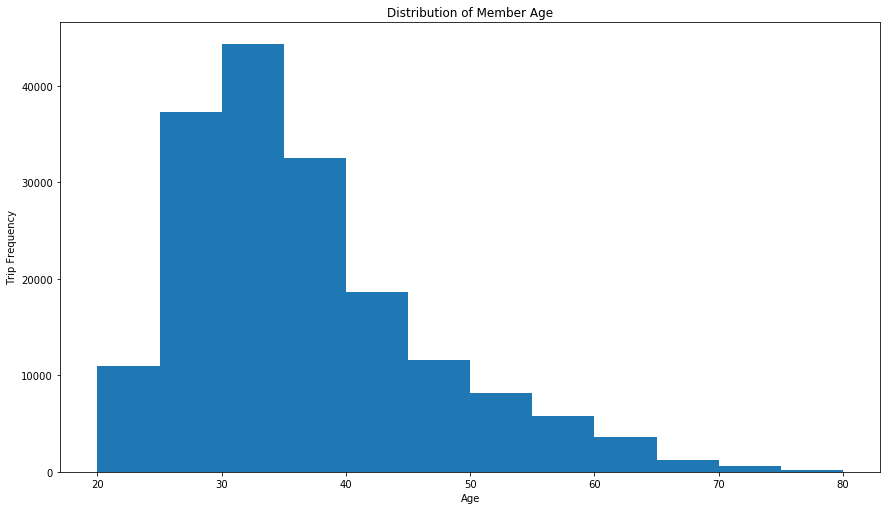

```python
myPlt("Distribution of Member Age", "Age", "Trip Frequency");
age_hist()
```

I don't really feel like I'm getting to much info from this histogram, so I'm going to try and scale it, so we can get a more accurate view on the ages with the most trips, and the lowest member age.

```python
def age_scale():
    bins = np.arange(0, trip['age'].max() + 1, 1)
    plt.hist(data = trip, x = 'age', bins = bins)
    plt.xlim((20, 80))
```

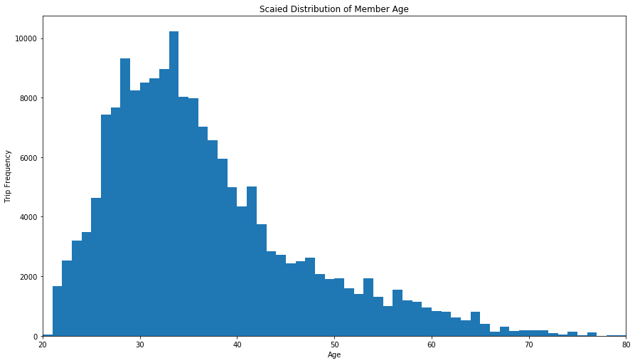

```python
myPlt("Scaied Distribution of Member Age", "Age", "Trip Frequency");
age_scale()
```

I attempted to log scale `age`, but it was getting a bit convoluted. So, let's try custom scaling it! I am interested in getting a deeper look into this variable.

```python
def age_cus():
    def sqrt_trans(x, inverse = False):
        if not inverse:
            return np.sqrt(x)
        else:
            return x ** 2

    bin_edges = np.arange(0, sqrt_trans(trip['age'].max()) + 1, 1)
    plt.hist(trip['age'].apply(sqrt_trans), bins = bin_edges)
    tick_locs = np.arange(0, sqrt_trans(trip['age'].max()) + 1, 1)
    plt.xticks(tick_locs, sqrt_trans(tick_locs, inverse = True).astype(int));
```

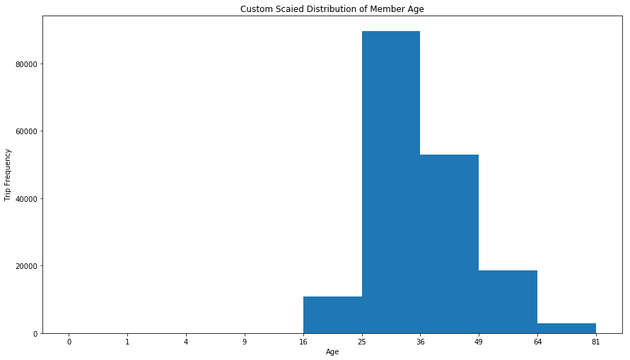

```python
myPlt("Custom Scaied Distribution of Member Age", "Age", "Trip Frequency");
age_cus()
```

### Distance

I am interested (as stated before) in how the distance of each trip actually affected the duration of the trips. I could also find out what the correlation between the amount of trips and the distance between start and end stations. I attempted to calculate distance during my cleaning phase; however, I felt it more appropriate to do so while introducing a new variable (because I am a sucker for epic introductions!).

```python
# defining distance
def haversine_vector(lon1, lat1, lon2, lat2):

    lon1, lat1, lon2, lat2 = map(np.radians, [lon1, lat1, lon2, lat2])

    newlon = lon2 - lon1
    newlat = lat2 - lat1

    haver_formula = np.sin(newlat/2.0) ** 2 + np.cos(lat1) * np.cos(lat2) * np.sin(newlon/2.0) ** 2

    dist = 2 * np.arcsin(np.sqrt(haver_formula))
    miles = 3959 * dist

    return miles

#creating dataframes for both locations
global_distance = pd.DataFrame({
    'lat_start' : trip['start_station_latitude'],
    'lon_start' : trip['start_station_longitude'],
    'lat_end' : trip['end_station_latitude'],
    'lon_end' : trip['end_station_longitude']}, index = trip.start_station_id)

# resetting index
global_distance.reset_index(inplace = True)
```

```python
trip['distance'] = haversine_vector(global_distance['lon_start'], global_distance['lat_start'], global_distance['lon_end'], global_distance['lat_end'])
```

```python
trip.head()
```

|  | duration_sec | start_time | end_time | start_station_id | start_station_name | start_station_latitude | start_station_longitude | end_station_id | ... | end_station_longitude | bike_id | user_type | member_birth_year | member_gender | bike_share_for_all_trip | age | distance |
| --- | --- | --- | --- | --- | --- | --- | --- | --- | --- | --- | --- | --- | --- | --- | --- | --- | --- |
| 0 | 52185 | 2019-02-28 17:32:10.145 | 2019-03-01 08:01:55.975 | 21.0 | Montgomery St BART Station (Market St at 2nd St) | 37.789625 | -122.400811 | 13.0 | ... | -122.402923 | 4902 | Customer | 1984.0 | Male | False | 37 | 0.658456 |
| 2 | 61854 | 2019-02-28 12:13:13.218 | 2019-03-01 05:24:08.146 | 86.0 | Market St at Dolores St | 37.769305 | -122.426826 | 3.0 | ... | -122.404904 | 5905 | Customer | 1972.0 | Male | False | 49 | 0.279519 |
| 3 | 36490 | 2019-02-28 17:54:26.010 | 2019-03-01 04:02:36.842 | 375.0 | Grove St at Masonic Ave | 37.774836 | -122.446546 | 70.0 | ... | -122.444293 | 6638 | Subscriber | 1989.0 | Other | False | 32 | 2.816581 |
| 4 | 1585 | 2019-02-28 23:54:18.549 | 2019-03-01 00:20:44.074 | 7.0 | Frank H Ogawa Plaza | 37.804562 | -122.271738 | 222.0 | ... | -122.248780 | 4898 | Subscriber | 1974.0 | Male | True | 47 | 0.717797 |
| 5 | 1793 | 2019-02-28 23:49:58.632 | 2019-03-01 00:19:51.760 | 93.0 | 4th St at Mission Bay Blvd S | 37.770407 | -122.391198 | 323.0 | ... | -122.405950 | 5200 | Subscriber | 1959.0 | Male | False | 62 | 0.722712 |

5 rows × 18 columns

```python
trip.describe()
```

|  | duration_sec | start_station_id | start_station_latitude | start_station_longitude | end_station_id | end_station_latitude | end_station_longitude | bike_id | member_birth_year | age | distance |
| --- | --- | --- | --- | --- | --- | --- | --- | --- | --- | --- | --- |
| count | 174944.000000 | 174749.000000 | 174944.000000 | 174944.000000 | 174749.000000 | 174944.000000 | 174944.000000 | 174944.000000 | 174944.000000 | 174944.000000 | 160177.000000 |
| mean | 704.509574 | 139.024092 | 37.770794 | -122.351263 | 136.643683 | 37.770989 | -122.350839 | 4481.980182 | 1984.880888 | 36.119112 | 0.973466 |
| std | 1642.477572 | 111.651112 | 0.101124 | 0.118499 | 111.352470 | 0.101031 | 0.118064 | 1658.354801 | 9.869501 | 9.869501 | 0.717070 |
| min | 61.000000 | 3.000000 | 37.317298 | -122.453704 | 3.000000 | 37.317298 | -122.453704 | 11.000000 | 1941.000000 | 20.000000 | 0.000000 |
| 25% | 323.000000 | 47.000000 | 37.770407 | -122.411901 | 44.000000 | 37.770407 | -122.411647 | 3802.000000 | 1980.000000 | 29.000000 | 0.479126 |
| 50% | 511.000000 | 104.000000 | 37.780760 | -122.398279 | 101.000000 | 37.781010 | -122.397405 | 4959.000000 | 1987.000000 | 34.000000 | 0.779871 |
| 75% | 789.000000 | 239.000000 | 37.797320 | -122.282497 | 238.000000 | 37.797673 | -122.285171 | 5505.000000 | 1992.000000 | 41.000000 | 1.408283 |
| max | 84548.000000 | 398.000000 | 37.880222 | -121.874119 | 398.000000 | 37.880222 | -121.874119 | 6645.000000 | 2001.000000 | 80.000000 | 5.545736 |

```python
def dist_hist():
    bins = np.arange(1, trip['distance'].max() + 0.5, 0.5)
    plt.hist(trip['distance'], bins = bins)
```

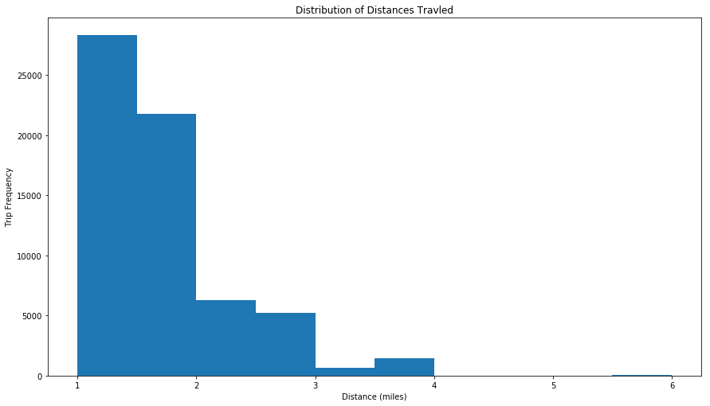

```python
myPlt("Distribution of Distances Travled", "Distance (miles)", "Trip Frequency");
dist_hist()
```

It looks like the trips didn't seem to go any further than 6 miles, with a cliff of trips being around 1 mile long. This is very helpful! But, I want to dive deeper. Maybe, something else will present itself.

```python
#plotting
def deep_hist():
    binsize = 0.2
    bins = np.arange(0, trip['distance'].max()+binsize, binsize)
    plt.hist(data = trip, x = 'distance', bins = bins)
    plt.show()
```

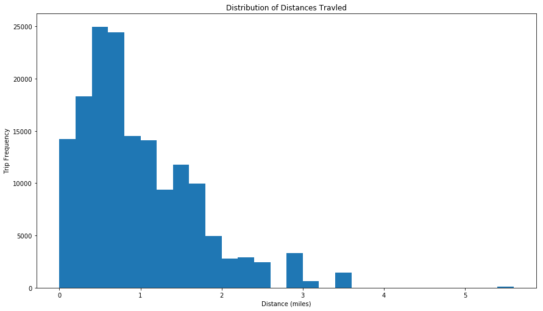

```python
myPlt("Distribution of Distances Travled", "Distance (miles)", "Trip Frequency");
deep_hist()
```

I scaled the plot out to see exactly where the start and end of `distance`'s range. You can see though that a good amount of trips were actually less than a mile long, despite what we saw earlier. Let's look deeper!

```python
def dis_sca():
    bins = np.arange(0, trip['distance'].max()  + 0.1, 0.1)
    plt.hist(data = trip, x = 'distance', bins = bins)
    plt.xlim((0,6))
```

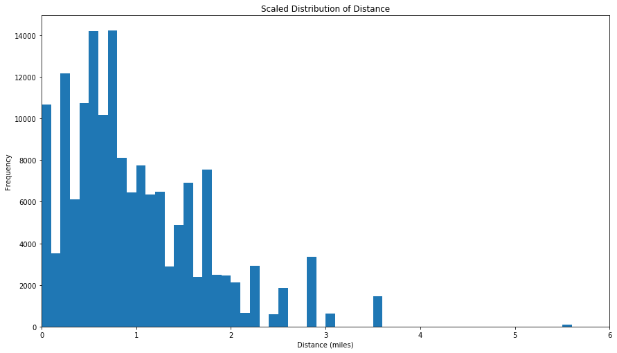

```python
myPlt("Scaled Distribution of Distance", "Distance (miles)", "Frequency");
dis_sca()
```

Here you can see that I used a scaled plot, to see even further into this subsection of data. It's becoming clearer the further I dive, that `distance` is not what it seems entirely.

```python
def dis_log():
    log_binsize = .035
    bins = 10 ** np.arange(.008825, np.log10(trip['distance'].max()) + log_binsize, log_binsize)

    plt.hist(data = trip, x = 'distance', bins = bins)
    plt.xscale('log')
    plt.xticks([0.3, 0.4, 0.5, 0.75, 1.0, 1.5, 2, 3, 4, 4.5, 5, 6], [0.3, '0.4', '0.5', '0.75', '1.0', '1.5', '2', '3', '4', '4.5', '5', '6'])
    plt.show()
```

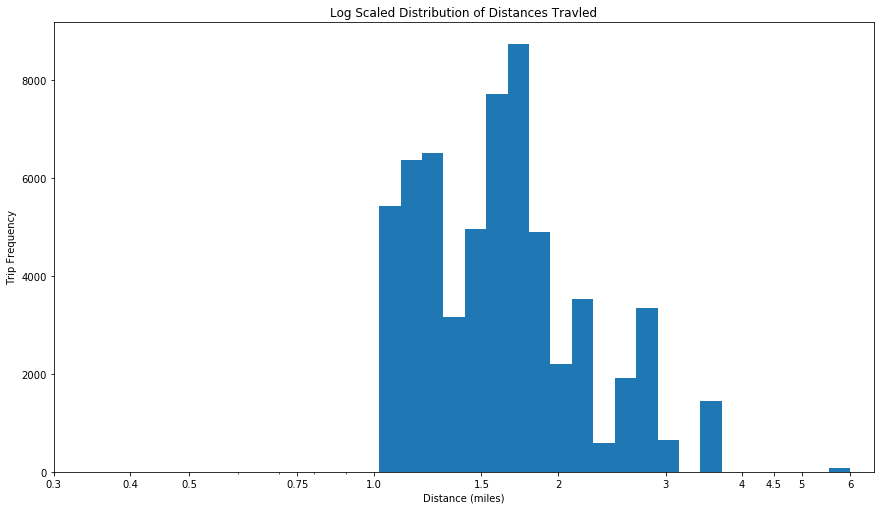

```python
myPlt("Log Scaled Distribution of Distances Travled", "Distance (miles)", "Trip Frequency");
dis_log()
```

Now that I've log scale plotted for `distance`, I can see that there are a lot of trips taken in between 1.5 and 2 miles. This slightly bimodal plot shows that not many trips go further than 6 miles. Actually the furthest looks to be just under 6 miles, when I thought there might be some trips that went further. I wonder what the break down for rider types is? That could definitely shed some light on who's riding further!

### Discuss the distribution(s) of your variable(s) of interest. Were there any unusual points? Did you need to perform any transformations?

Unexpectedly, the distance variable is **not** unimodal like the previous two variables we've explored. When I dove into plotting a simple histogram, I initially thought it was going to be. It definitely looked like it was going to be. Even as I scaled the plot to see where the initial cliff started, the variable was looking to be an ordinal. However when I log scaled the plot I realized it was actually **bimodal**. You can also see that a good amount of trips were in between 1.5 miles and 2 miles. With what we know about the `age` and `duration_sec` variables, I'd say San Francisco has some very impressive commuter cyclists!

### Of the features you investigated, were there any unusual distributions? Did you perform any operations on the data to tidy, adjust, or change the form of the data? If so, why did you do this?

I was extra proud of the fact that I was able to figure out how to calculate the distance between two GPS locations (start longitude and latitude, and end longitude and latitude) in order to see how far riders were traveling. I had to try a few different approaches for this portion of cleaning, which included a ton of trial and error. I also had to calculate the age of each rider/member. Both processes were challenging in some ways, but I felt it was necessary to calculate distance traveled for riders (as I believe its an important numerical variable to have), and to calculate each rider/member's age (as I believe its important to have a numerical variable directly reflecting the riders specifically, and not the trips).

### Extra Univariate Plotting

```python
def cat_uni_plot():
    # plotting categorical variables

    fig, ax = plt.subplots(nrows = 2, figsize = [10, 8])

    default_color = sb.color_palette()[0]
    user = sb.countplot(data = trip, x = 'user_type', color = default_color, ax = ax[0])
    user.set(xlabel = 'User', ylabel = 'Trip Frequency')
    gender = sb.countplot(data = trip, x = 'member_gender', color = default_color, ax = ax[1])
    gender.set(xlabel = 'Gender', ylabel = 'Trip Frequency')
    plt.suptitle('Distributions of User Types and Gender per Trip', y = 1.04)
    plt.tight_layout()
    plt.show()
```

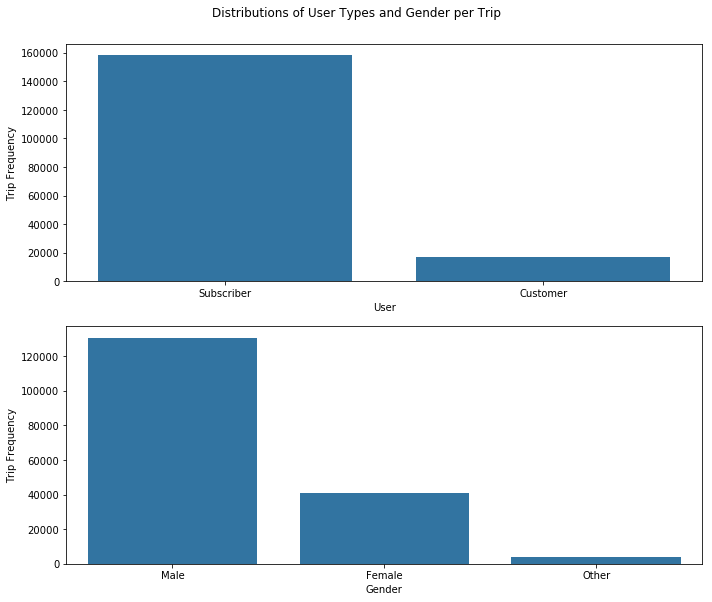

```python
cat_uni_plot()
```

Here I wanted to give quick glimpse at the two categorical variables I'll be exploring. As you can see there are more Subscribers than Customers for `user_type` and for `member_gender` the plot suggests that the majority of trips were taken by male riders. Female riders and riders who identified as, Other, coming in a not-so-close second and third.

## Bivariate Exploration

```python
def stackedplot():
    cat1_order = ['Male', 'Female', 'Other']
    cat2_order = ['Subscriber', 'Customer']

    plt.figure(figsize = [13, 5])

    # left plot: clustered bar chart, absolute counts
    plt.subplot(1, 2, 1)
    gender = sb.countplot(data = trip, x = 'member_gender', hue = 'user_type',
                 order = cat1_order, hue_order = cat2_order)
    gender.set(xlabel = 'Gender', ylabel = 'Trip Frequency')
    plt.legend()

    # right plot: stacked bar chart, absolute counts
    plt.subplot(1, 2, 2)

    baselines = np.zeros(len(cat1_order))
    # for each second-variable category:
    for i in range(len(cat2_order)):
            # isolate the counts of the first category,
            cat2 = cat2_order[i]
            inner_counts = trip[trip['user_type'] == cat2]['member_gender'].value_counts()
            # then plot those counts on top of the accumulated baseline
            plt.bar(x = np.arange(len(cat1_order)), height = inner_counts[cat1_order],
                    bottom = baselines)
            plt.xlabel('Gender')
            plt.ylabel('Trip Frequency')
            baselines += inner_counts[cat1_order]

    plt.suptitle('Distributions of User Types by Gender per Trip', y = 1.04)
    plt.tight_layout()
    plt.xticks(np.arange(len(cat1_order)), cat1_order)
    plt.legend(cat2_order)
```

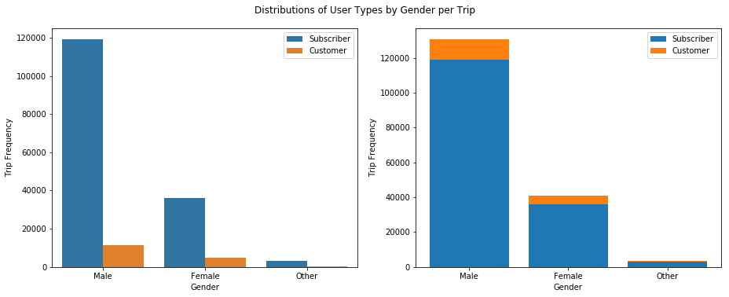

```python
stackedplot()
```

I wanted to showcase a stacked plot to show the relationship between categorical variables `user_type` and `member_gender` I believe it's important to show these as I will be comparing these two variables against the numerical variables I explored earlier in this analysis.

### User Type:

Let's see how the numerical values are represented via `user_type`.

```python
def facetedplot(df, grpVar, var, bins, threshold, limit = False, cwrap = 2):

    THRESHOLD = threshold
    user_frequency = df[grpVar].value_counts()
    idx = np.sum(user_frequency > THRESHOLD)

    most_users = user_frequency.index[:idx]
    trip_sub = df.loc[df[grpVar].isin(most_users)]

    user_means = trip_sub.groupby(grpVar).mean()
    comb_order = user_means.sort_values(var, ascending = False).index

    # plotting
    g = sb.FacetGrid(data = trip_sub, col = grpVar, col_wrap = cwrap, height = 5,
                       col_order = comb_order)
    if limit:
        g.map(plt.hist, var,
              bins = np.arange(trip_sub[var].min(), trip_sub[var].quantile(limit) + bins, bins),
              edgecolor = 'black')
    else:
        g.map(plt.hist, var,
              bins = np.arange(trip_sub[var].min(), trip_sub[var].max() + bins, bins),
              edgecolor = 'black')

    g.set_titles('{col_name}')

    g.fig.suptitle(f"Distribution of {var.replace('_', ' ')} by {grpVar.replace('_', ' ')}".title(),
                   y = 1.01,
                   fontsize = 14,
                   weight = "bold");
    if var == 'duration_sec':
        g.set(xlabel = var.replace('duration_sec', 'Duration (sec)'), ylabel = "Trip Frequency")
    elif var == 'age':
        g.set(xlabel = var.title(), ylabel = "Trip Frequency")
    elif var == 'distance':
        g.set(xlabel = var.title(), ylabel = "Trip Frequency")

    g.fig.set_size_inches(14.70, 8.27)
```

```python
def user_duration():
    plt.figure(figsize = [20, 9])
    base_color = sb.color_palette()[0]

    # left plot: violin plot
    plt.subplot(1, 3, 1)
    ax = sb.violinplot(data = trip, x = 'user_type', y= 'duration_sec', inner = None,
                      color = base_color)
    ax.set_xlabel("User Type")
    ax.set_ylabel("Duration (sec)")
    plt.xticks(rotation = 45); # include label rotation due to small subplot size


    # center plot: box plot
    plt.subplot(1, 3, 2)
    ax = sb.boxplot(data = trip, x = 'user_type', y = 'duration_sec', color = base_color)
    ax.set_xlabel("User Type")
    ax.set_ylabel("Duration (sec)")
    plt.xticks(rotation = 45);

    # right plot: adapted bar chart
    plt.subplot(1, 3, 3)
    ax = sb.barplot(data = trip, x = 'user_type', y = 'duration_sec', color = base_color)
    ax.set(xlabel = 'User Type', ylabel = 'Duration (sec)')
    plt.xticks(rotation = 45);

    plt.suptitle('Distributions of User Types by Duration per Trip', y = 1.04)
    plt.tight_layout()
    plt.show
```

```python
def user_age():
    plt.figure(figsize = [20, 9])
    base_color = sb.color_palette()[0]

    # left plot: violin plot
    plt.subplot(1, 3, 1)
    ax = sb.violinplot(data = trip, x = 'user_type', y= 'age', inner = None,
                      color = base_color)
    ax.set_xlabel("User Type")
    ax.set_ylabel("Age")
    plt.xticks(rotation = 45); # include label rotation due to small subplot size


    # center plot: box plot
    plt.subplot(1, 3, 2)
    ax = sb.boxplot(data = trip, x = 'user_type', y = 'age', color = base_color)
    ax.set_xlabel("User Type")
    ax.set_ylabel("Age")
    plt.xticks(rotation = 45);

    # right plot: adapted bar chart
    plt.subplot(1, 3, 3)
    ax = sb.barplot(data = trip, x = 'user_type', y = 'age', color = base_color)
    ax.set(xlabel = 'User Type', ylabel = 'Age')
    plt.xticks(rotation = 45);

    plt.suptitle('Distributions of User Types by Age per Trip', y = 1.04)
    plt.tight_layout()
    plt.show
```

```python
def user_distance():
    plt.figure(figsize = [20, 9])
    base_color = sb.color_palette()[0]

    # left plot: violin plot
    plt.subplot(1, 3, 1)
    ax = sb.violinplot(data = trip, x = 'user_type', y= 'distance', inner = None,
                      color = base_color)
    ax.set_xlabel("User Type")
    ax.set_ylabel("Distance (mi)")
    plt.xticks(rotation = 45); # include label rotation due to small subplot size


    # center plot: box plot
    plt.subplot(1, 3, 2)
    ax = sb.boxplot(data = trip, x = 'user_type', y = 'distance', color = base_color)
    ax.set_xlabel("User Type")
    ax.set_ylabel("Distance (mi)")
    plt.xticks(rotation = 45);

    # right plot: adapted bar chart
    plt.subplot(1, 3, 3)
    ax = sb.barplot(data = trip, x = 'user_type', y = 'distance', color = base_color)
    ax.set(xlabel = 'User Type', ylabel = 'Distance (mi)')
    plt.xticks(rotation = 45);

    plt.suptitle('Distributions of User Types by Distance per Trip', y = 1.04)
    plt.tight_layout()
    plt.show
```

Now to start plotting!

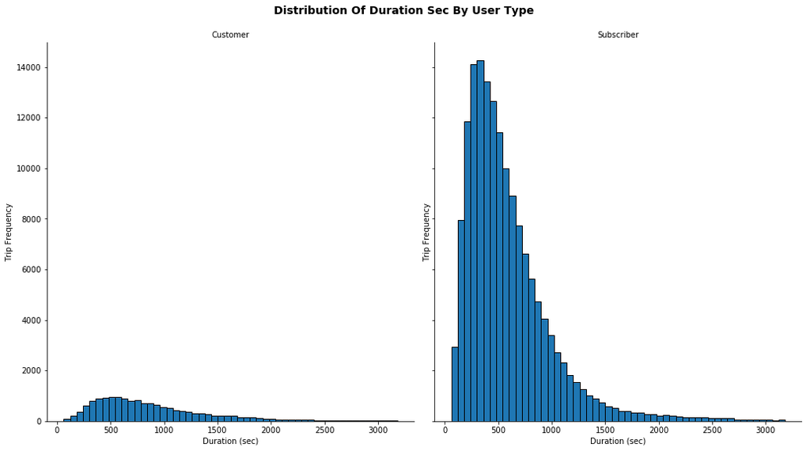

```python
facetedplot(trip, 'user_type', 'duration_sec', 60, 10000, limit = 0.99)
```

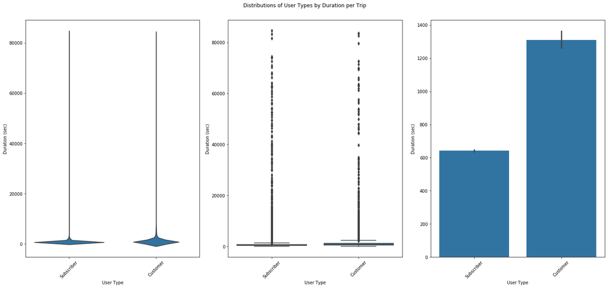

```python
user_duration()
```

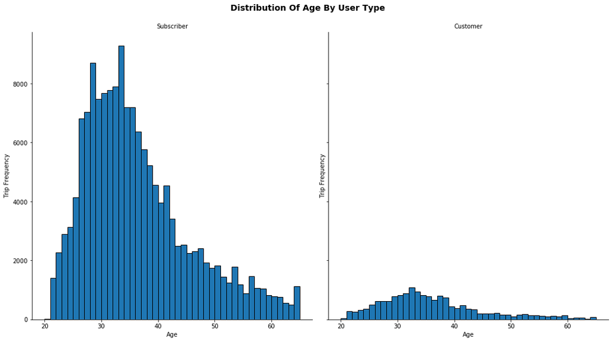

```python
facetedplot(trip, 'user_type', 'age', 1, 80, limit = 0.99)
```

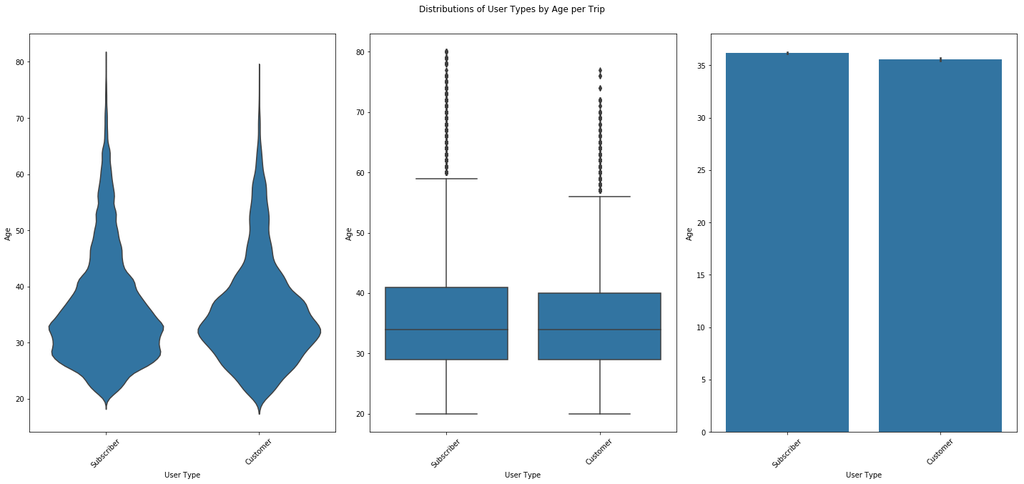

```python
user_age()
```

Interestingly enough, you can see that the age range for both categories are relatively similar. From the naked eye they could be perceived as the same range, but if you take a closer look, subscribers have a wider age range than customers do.

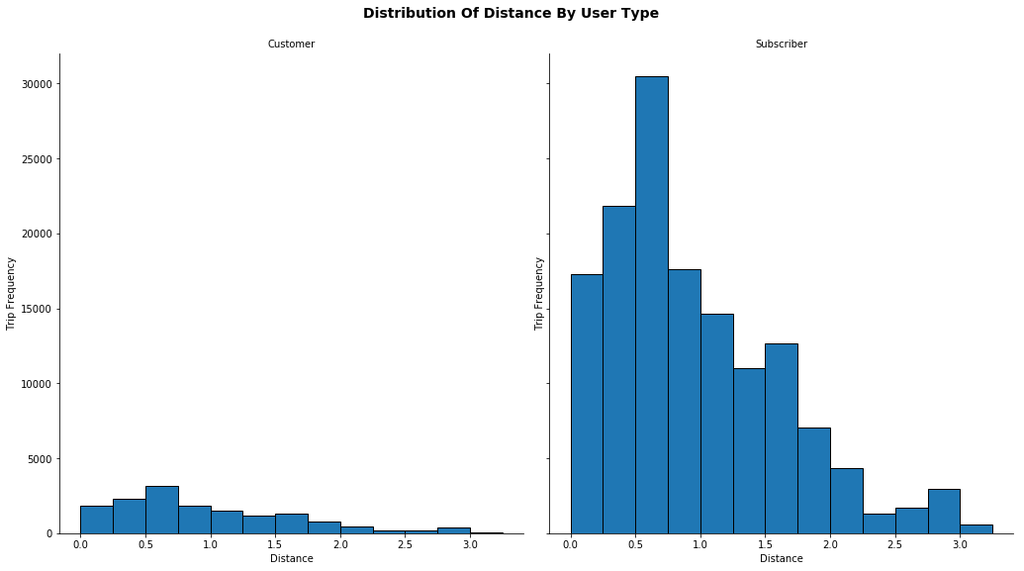

```python
facetedplot(trip, 'user_type', 'distance', 0.25, 1, limit = 0.99)
```

Here you can see that `distance` is behaving similarly to both `age` and `duration_sec` when split into the `user_type` categories. It looks like there are a lot of trips that were less than a mile for both user types. You can see the spike right around half a mile, and a trail off around 3 miles.

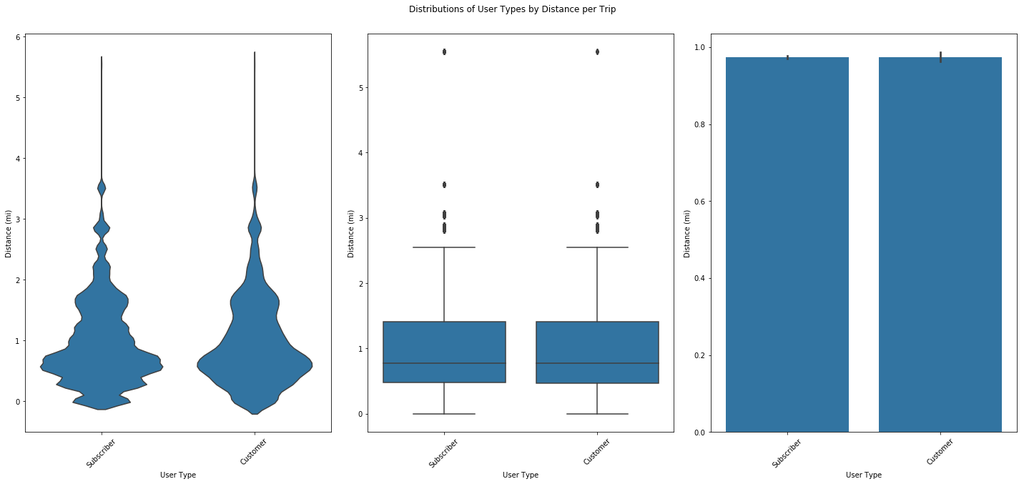

```python
user_distance()
```

### Member Gender:

Let's see how the numerical values are represented via `member_gender`

```python
def barplot1():

    THRESHOLD = 80
    gender_frequency = trip['member_gender'].value_counts()
    idx = np.sum(gender_frequency > THRESHOLD)

    most_genders = gender_frequency.index[:idx]
    trip_sub = trip.loc[trip['member_gender'].isin(most_genders)]

    gender_means = trip_sub.groupby('member_gender').mean()
    comb_order = gender_means.sort_values('duration_sec', ascending = False).index

    # plotting
    base_color = sb.color_palette()[0]
    ax = sb.barplot(data = trip_sub, x = 'duration_sec', y = 'member_gender',
                color = base_color, order = comb_order, ci = 'sd')
    ax.set(xlabel = 'Duration (sec)', ylabel = 'Member Gender')
```

```python
def barplot2():

    THRESHOLD = 80
    gender_frequency = trip['member_gender'].value_counts()
    idx = np.sum(gender_frequency > THRESHOLD)

    most_genders = gender_frequency.index[:idx]
    trip_sub = trip.loc[trip['member_gender'].isin(most_genders)]

    gender_means = trip_sub.groupby('member_gender').mean()
    comb_order = gender_means.sort_values('age', ascending = False).index

    # plotting
    base_color = sb.color_palette()[0]
    ax = sb.barplot(data = trip_sub, x = 'age', y = 'member_gender',
                color = base_color, order = comb_order, ci = 'sd')
    ax.set(xlabel = 'Age', ylabel = 'Member Gender')
```

```python
def barplot3():

    THRESHOLD = 80
    gender_frequency = trip['member_gender'].value_counts()
    idx = np.sum(gender_frequency > THRESHOLD)

    most_genders = gender_frequency.index[:idx]
    trip_sub = trip.loc[trip['member_gender'].isin(most_genders)]

    gender_means = trip_sub.groupby('member_gender').mean()
    comb_order = gender_means.sort_values('distance', ascending = False).index

    # plotting
    base_color = sb.color_palette()[0]
    ax = sb.barplot(data = trip_sub, x = 'distance', y = 'member_gender',
                color = base_color, order = comb_order, ci = 'sd')
    ax.set(xlabel = 'Distance (mi)', ylabel = 'Member Gender')
```

```python
def gender_duration():
    plt.figure(figsize = [20, 9])
    base_color = sb.color_palette()[0]

    # left plot: violin plot
    plt.subplot(1, 3, 1)
    ax = sb.violinplot(data = trip, x = 'member_gender', y= 'duration_sec', inner = None,
                      color = base_color)
    ax.set_xlabel("Member Gender")
    ax.set_ylabel("Duration (sec)")
    plt.xticks(rotation = 45); # include label rotation due to small subplot size


    # center plot: box plot
    plt.subplot(1, 3, 2)
    ax = sb.boxplot(data = trip, x = 'member_gender', y = 'duration_sec', color = base_color)
    ax.set_xlabel("Member Gender")
    ax.set_ylabel("Duration (sec)")
    plt.xticks(rotation = 45);

    # right plot: adapted bar chart
    plt.subplot(1, 3, 3)
    ax = sb.barplot(data = trip, x = 'member_gender', y = 'duration_sec', color = base_color)
    ax.set(xlabel = 'Member Gender', ylabel = 'Duration (sec)')
    plt.xticks(rotation = 45);

    plt.suptitle('Distributions of Member Genders by Duration per Trip', y = 1.04)
    plt.tight_layout()
    plt.show
```

```python
def gender_age():
    plt.figure(figsize = [20, 9])
    base_color = sb.color_palette()[0]

    # left plot: violin plot
    plt.subplot(1, 3, 1)
    ax = sb.violinplot(data = trip, x = 'member_gender', y= 'age', inner = None,
                      color = base_color)
    ax.set_xlabel("Member Gender")
    ax.set_ylabel("Age")
    plt.xticks(rotation = 45); # include label rotation due to small subplot size


    # center plot: box plot
    plt.subplot(1, 3, 2)
    ax = sb.boxplot(data = trip, x = 'member_gender', y = 'age', color = base_color)
    ax.set_xlabel("Member Gender")
    ax.set_ylabel("Age")
    plt.xticks(rotation = 45);

    # right plot: adapted bar chart
    plt.subplot(1, 3, 3)
    ax = sb.barplot(data = trip, x = 'member_gender', y = 'age', color = base_color)
    ax.set(xlabel = 'Member Gender', ylabel = 'Age')
    plt.xticks(rotation = 45);

    plt.suptitle('Distributions of Member Genders by Age per Trip', y = 1.04)
    plt.tight_layout()
    plt.show
```

```python
def gender_distance():
    plt.figure(figsize = [20, 9])
    base_color = sb.color_palette()[0]

    # left plot: violin plot
    plt.subplot(1, 3, 1)
    ax = sb.violinplot(data = trip, x = 'member_gender', y= 'distance', inner = None,
                      color = base_color)
    ax.set_xlabel("Member Gender")
    ax.set_ylabel("Distance (mi)")
    plt.xticks(rotation = 45); # include label rotation due to small subplot size


    # center plot: box plot
    plt.subplot(1, 3, 2)
    ax = sb.boxplot(data = trip, x = 'member_gender', y = 'distance', color = base_color)
    ax.set_xlabel("Member Gender")
    ax.set_ylabel("Distance (mi)")
    plt.xticks(rotation = 45);

    # right plot: adapted bar chart
    plt.subplot(1, 3, 3)
    ax = sb.barplot(data = trip, x = 'member_gender', y = 'distance', color = base_color)
    ax.set(xlabel = 'Member Gender', ylabel = 'Distance (mi)')
    plt.xticks(rotation = 45);

    plt.suptitle('Distributions of Member Genders by Distance per Trip', y = 1.04)
    plt.tight_layout()
    plt.show
```